# Estudio sobre las tandas de penales realizadas en torneos internacionales de la división masculina de futbol

# Regresión

## Primer Modelo

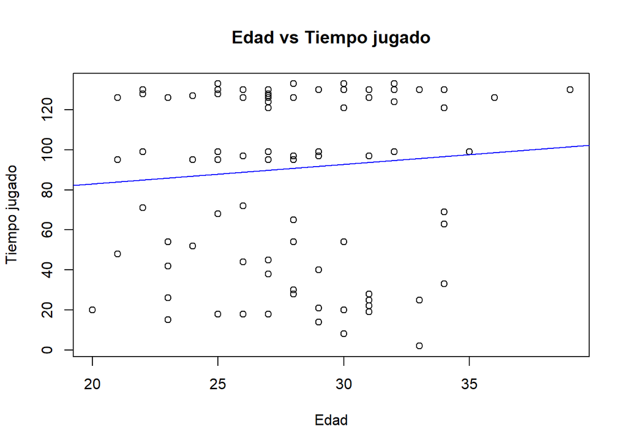

```r
modelo1 <- lm(Gols$Tiempo_J~Gols$Edad_J)
plot(Gols$Edad_J, Gols$Tiempo_J, xlab = "Edad",ylab = "Tiempo jugado",main = "Edad vs Tiempo jugado")

abline(modelo1,col= "blue")
```

Comentario:

En esta gráfica se expresa la variable independiente edad junto a su ordenada, tiempo de juego. Esta segunda variable es la que trataremos de predecir con esta regresión lineal.

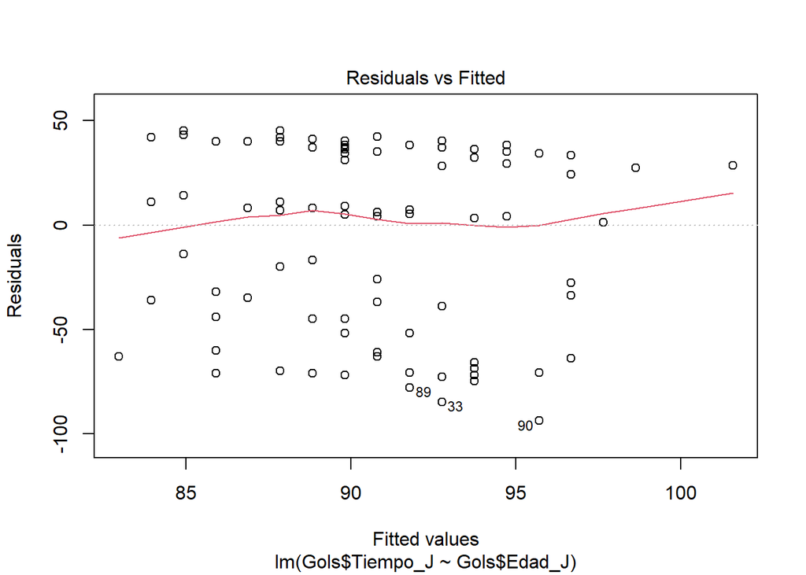

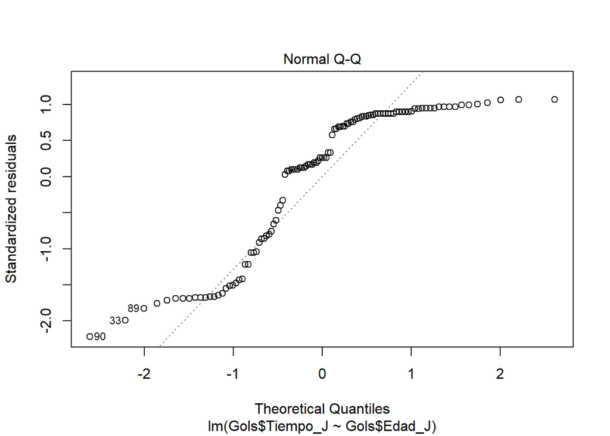

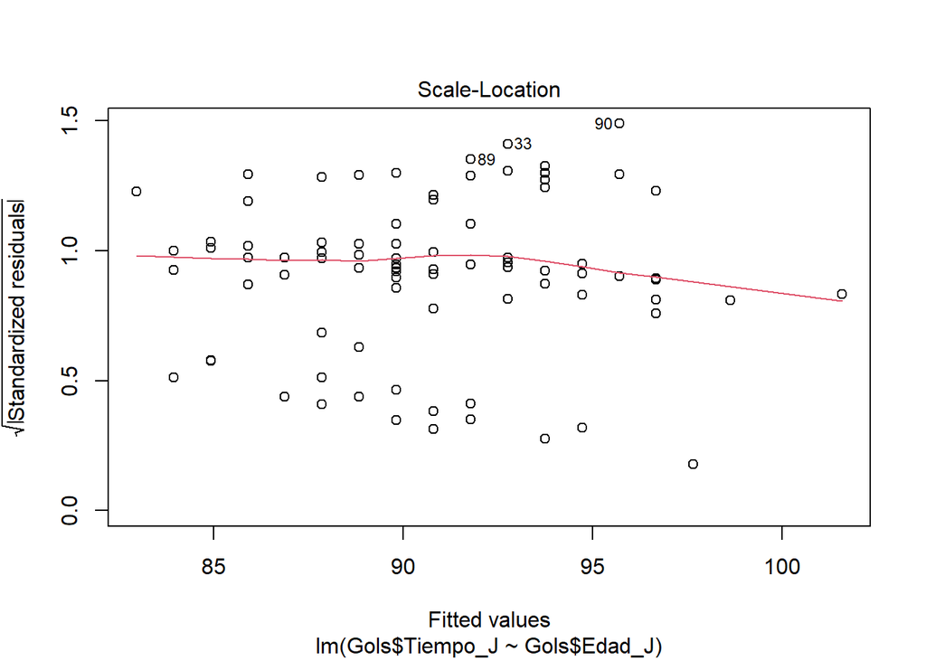

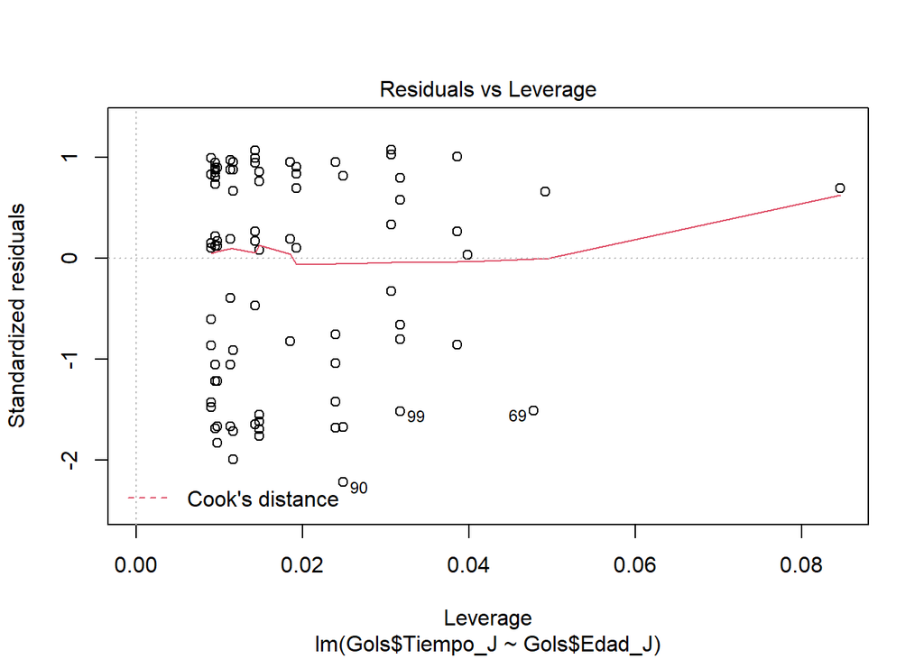

```r
plot(modelo1)
```

```r
summary(modelo1)
```

```
##
## Call:
## lm(formula = Gols$Tiempo_J ~ Gols$Edad_J)
##
## Residuals:
##    Min     1Q Median     3Q    Max
## -93.71 -36.38  11.13  37.20  45.13
##
## Coefficients:
##             Estimate Std. Error t value Pr(>|t|)
## (Intercept)  63.3708    29.9418   2.116   0.0366 *
## Gols$Edad_J   0.9799     1.0622   0.923   0.3583
## ---
## Signif. codes:  0 '***' 0.001 '**' 0.01 '*' 0.05 '.' 0.1 ' ' 1
##
## Residual standard error: 42.77 on 109 degrees of freedom
## Multiple R-squared:  0.007748,   Adjusted R-squared:  -0.001355
## F-statistic: 0.8511 on 1 and 109 DF,  p-value: 0.3583
```

Observación al modelo:

En este primer modelo planteamos la relación entre la variable independiente edad junto a su  
ordenada, tiempo de juego. Para poder predecir cuánto tiempo estará un jugador en la cancha basándonos en su edad.

Antes de saltar a las conclusiones es vital realizar un análisis de residuos, para  
ello usaremos las gráficas de diagnóstico.

En la primera gráfica esperamos observar la homocedasticidad de los datos. Que podria simplificarse en qué tan grande es el error de los datos. Se esperaría que esta gráfica se vea como una especie de nube con una gran densidad alrededor del valor constante cero y que mientras más se aleje del mismo menos densa sea la nube. En este caso vemos cierta tendencia  
hacia el cero. Los resultados de esta primera gráfica no son realmente prometedores.

Para la segunda gráfica esperamos comprobar la distribución de residuos normal. Esta deberia verse como una serie de puntos sobre la línea punteada. Es evidente que en este primer modelo no ocurre esto, por lo que sabemos que la distribución de residuos no  
es normal.

La tercera gráfica nos muestra la raíz cuadrada del valor absoluto del  
residuo estandarizado, se espera que esta se centre cerca de la recta constante uno.  
Hasta el momento esta es la gráfica diagnóstica más prometedora. Es importante mencionar que los valores atípicos se vuelven a evidenciar en esta gráfica.

La última gráfica pretende mostrarnos el apalancamiento. Lo que buscamos aquí es que no haya datos con un residuo grande junto a una palanca grande. No es ninguna sorpresa para este punto  
que existan datos que encajen en esta descripción. Los datos más Ilamativos son: 90, 99 y 69.

Una vez realizado el análisis de residuos podemos pasar al resumen de la regresión. Yendo de  
arriba hacia abajo el primer problema que encontramos en esta regresión se encuentra en los residuos. Aquí la media deberia ser cercana a cero pero en su Iugar tenemos un 11.13 a su vez los módulos de min y max deberian ser similares al igual que los del primer cuartil y el tercero.

Ahora nos centraremos en el modelo de regresión identificado (Y = 63.3708 + 0.9799 X) para ver si es de utilidad para nosotros veremos las pruebas de hipótesis. Tanto para el intercepto como para la pendiente trataremos de rechazar la hipótesis de que el  
valor es cero. En el caso del intercepto trabajando con una significancia mayor al 4%  
podemos rechazar la hipótesis mientras que para la pendiente no podemos rechazarla.  
Hecho esto podemos observar los coeficientes de determinación los que nos muestran en  
grado de variación de Y que logramos explicar con el modelo y la variación de X. En nuestro caso es muy pequeño por lo que el modelo sólo explica menos del 1% de la variación  
de Y. Por último para ver la utilidad de toda la regresión observamos el p-value y nos encontramos con que necesitaríamos trabajar con una significancia de casi el 36% para que el modelo sea útil. Como este no es nuestro caso solo podemos concluir que este modelo no explica nada.

## Segundo Modelo

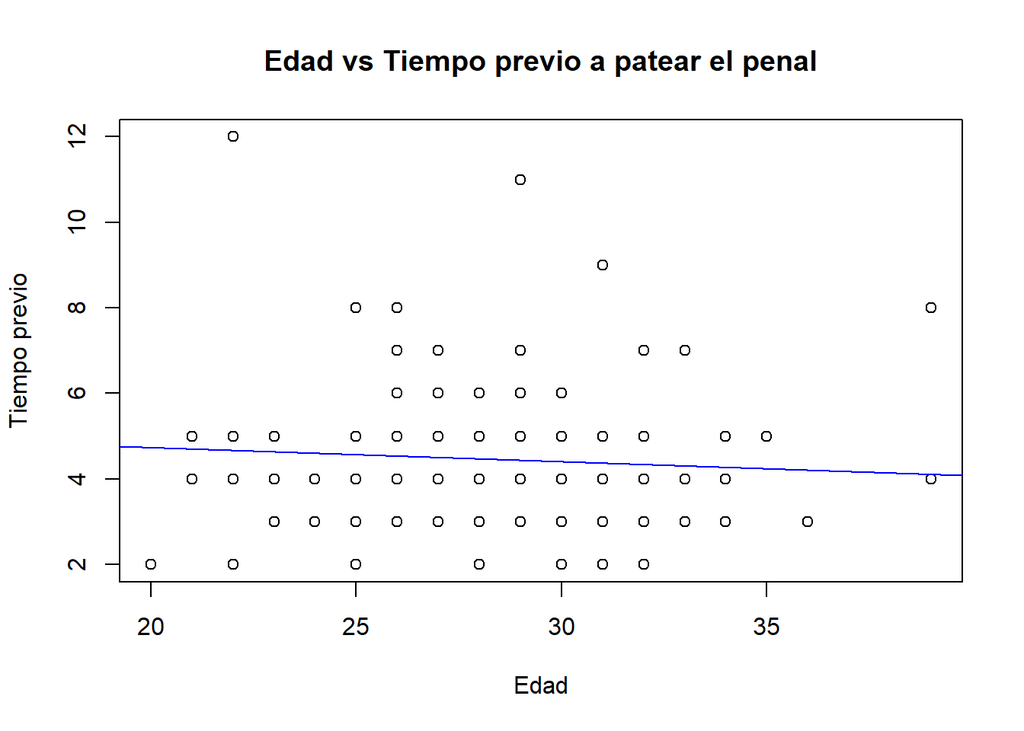

```r
modelo2 <- lm(Gols$Tiempo_Prev~Gols$Edad_J)
plot(Gols$Edad_J, Gols$Tiempo_Prev, xlab = "Edad",ylab = "Tiempo previo",main = "Edad vs Tiempo previo a patear el penal")

abline(modelo2,col= "blue")
```

Comentario: En esta segunda gráfica se pueden apreciar la variables independiente “Edad” junto a la dependiente “Tiempo previo”.

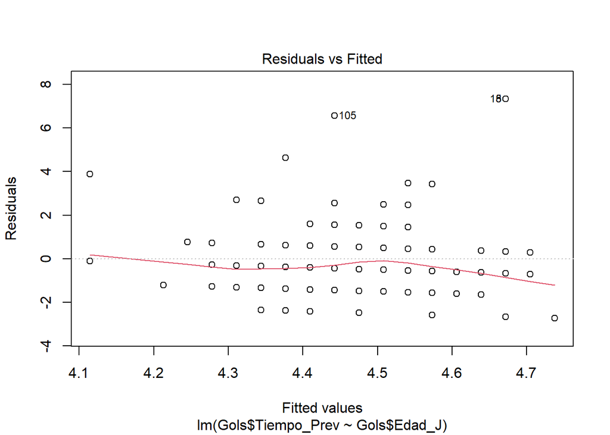

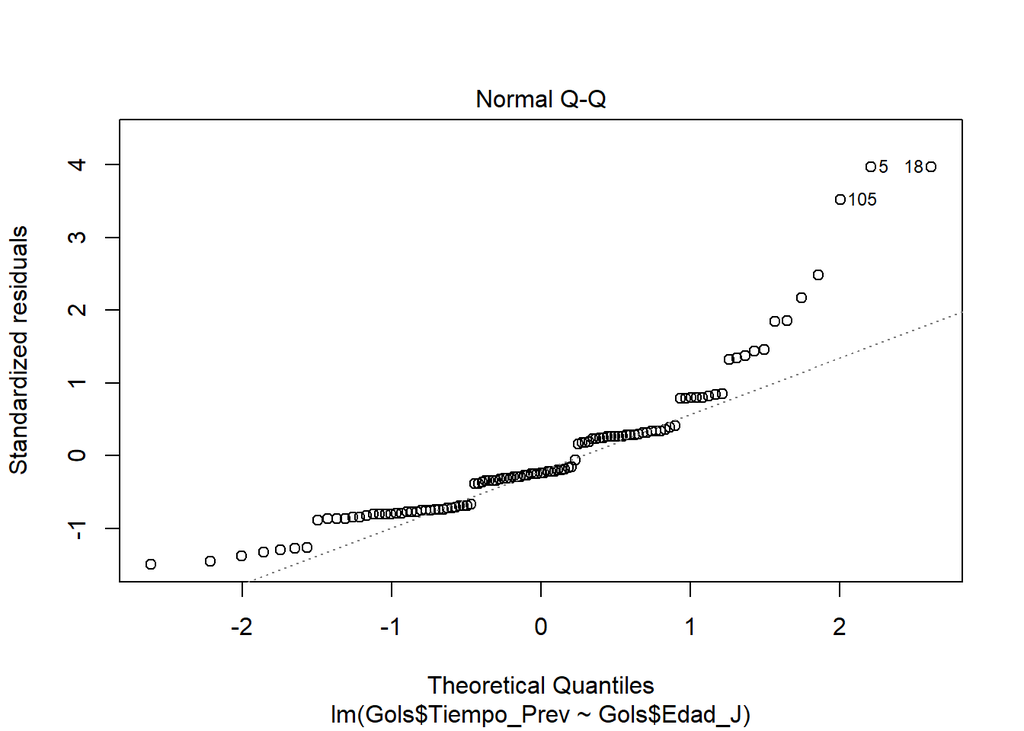

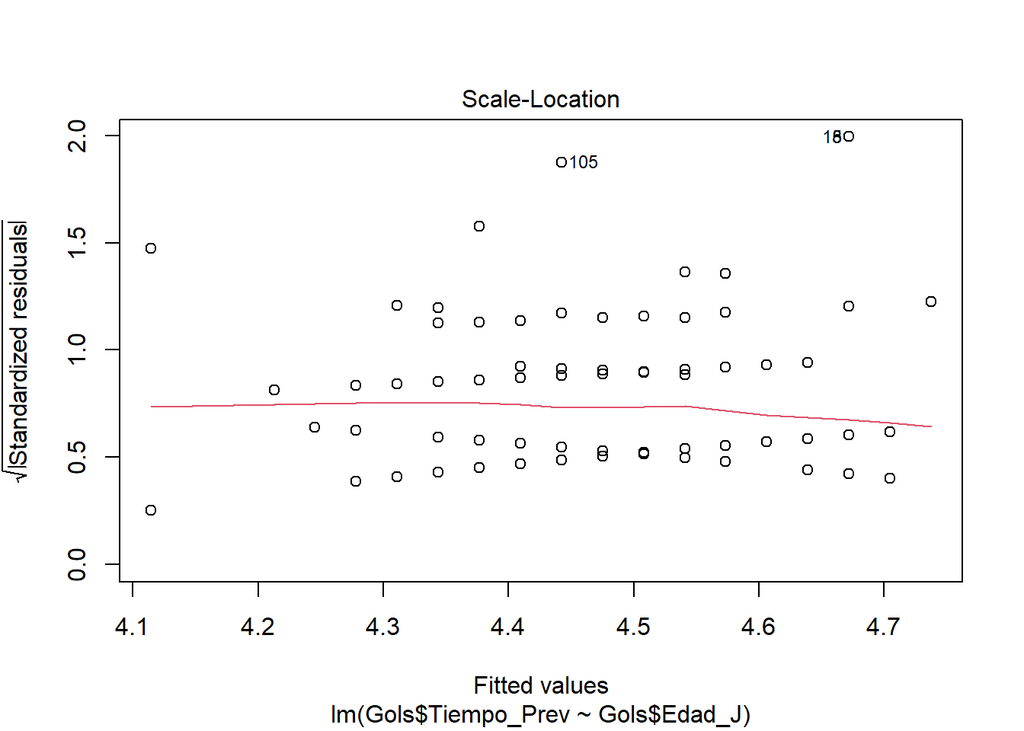

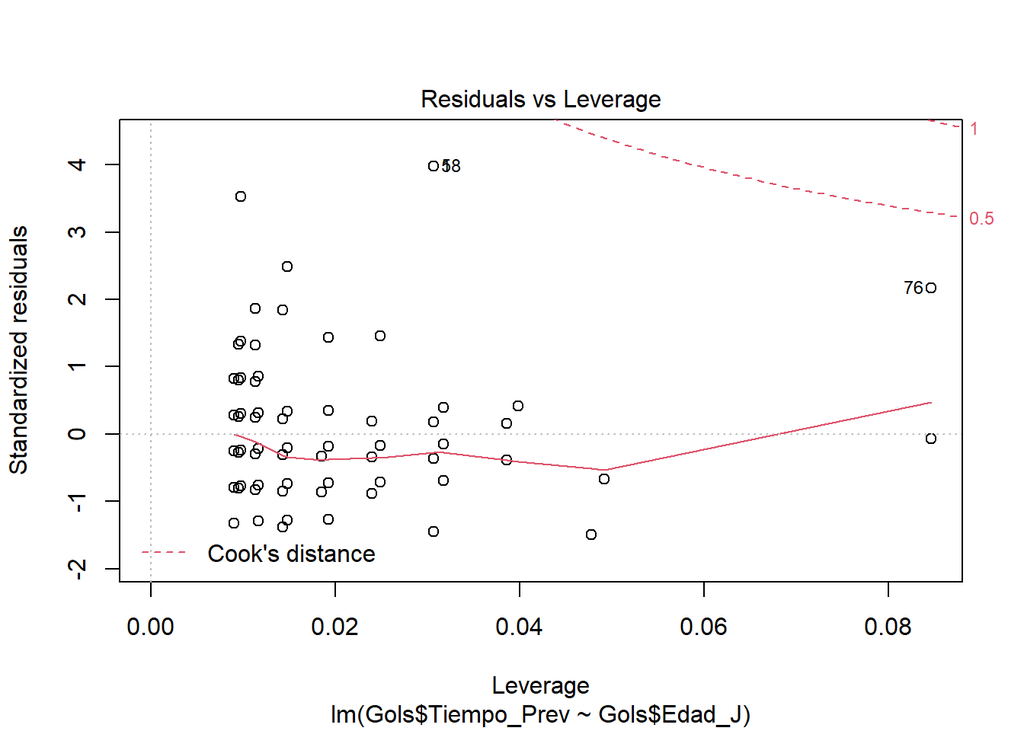

```r
plot(modelo2)
```

```r
summary(modelo2)
```

```
##
## Call:
## lm(formula = Gols$Tiempo_Prev ~ Gols$Edad_J)
##
## Residuals:
##     Min      1Q  Median      3Q     Max
## -2.7375 -1.3767 -0.4423  0.5741  7.3281
##
## Coefficients:
##             Estimate Std. Error t value Pr(>|t|)
## (Intercept)  5.39347    1.31042   4.116 7.52e-05 ***
## Gols$Edad_J -0.03280    0.04649  -0.706    0.482
## ---
## Signif. codes:  0 '***' 0.001 '**' 0.01 '*' 0.05 '.' 0.1 ' ' 1
##
## Residual standard error: 1.872 on 109 degrees of freedom
## Multiple R-squared:  0.004546,   Adjusted R-squared:  -0.004587
## F-statistic: 0.4978 on 1 and 109 DF,  p-value: 0.482
```

Observación al modelo: En este segundo modelo planteamos la relación entre la variable independiente edad junto a su ordenada, tiempo previo a patear un penal, con la esperanza de predecir el tiempo que le tomará a un jugador prepararse para la ejecución de un penal según su edad.

Antes de saltar a las conclusiones es vital realizar un análisis de residuos, para  
ello usaremos las gráficas de diagnóstico.

En la gráfica de la homocedasticidad podemos observar una nube de datos que de alguna forma  
tienden al cero como se esperaría de esta gráfica. El problema que que la línea roja no está realmente sobre la recta constante en cero.

Para la gráfica de Distribución de residuos es evidente que no siguen un modelo normal, se empiezan a observar cientos datos atípicos.

En la gráfica de la raíz cuadrada del valor absoluto del residuo estandarizado no se ve nada de lo esperado. En Iugar de que la línea roja sea una recta sobre la recta horizontal en 1 se encuentra por debajo del mismo.

En la gráfica de apalancamiento no vemos demasiados datos atípicos salvo del 58 o el 76.

Ahora pasamos al resumen de regresión, dentro del acápite de los residuos encontramos que  
la media se aproxima a cero sin embargo no hay simetría evidente en los valores absolutos de los cuartiles.

En el acápite del modelo propuesto (Y=5.39347 -0.03280 X) nos disponemos a analizar las pruebas  
de hipótesis. Encontramos que en el caso de la intersección se rechaza de manera holgada la hipótesis que sostiene que el coeficiente es cero por lo que el valor propuesto se puede utilizar con la significancia que venimos usando. En la otra cara de la moneda, no se pudo rechazar la hipótesis de que la pendiente sea igual a cero sugiriendo que el valor de la pendiente no es  
realmente fidedigno. Pasamos a revisar los coeficientes de determinación los que nos dicen  
qué grado de variación de Y podemos explicar con el modelo y la variación de X. En este caso solo podemos explicar el 0.4% del modelo con esta regresión. Esto sumado a que no  
pudimos rechazar la prueba de hipótesis “p-value” nos termina dictando que esta regresión no es útil.

## Tercer Modelo

```r
GOlsA <- DF_A %>% filter(Resultado_P == "Gol") # Estatura del arquero a quien le han metido gol
```

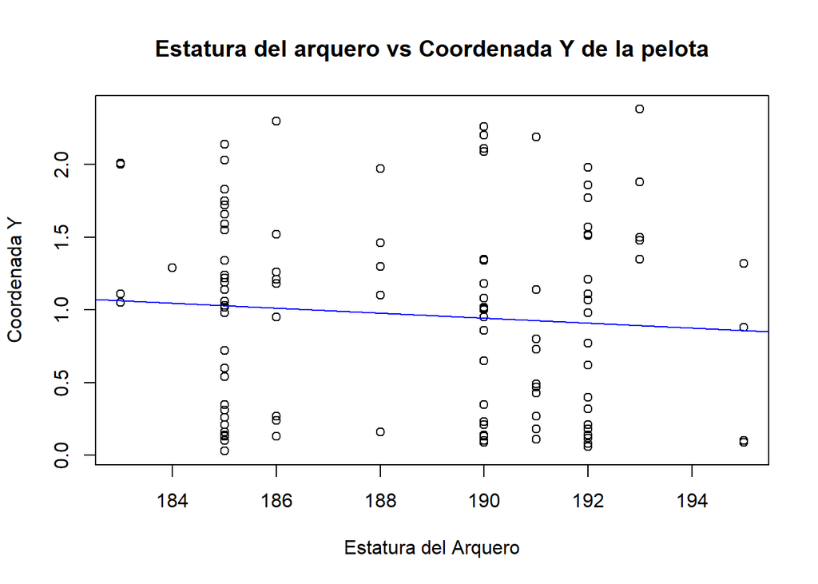

```r
modelo3 <- lm(Gols$Coordenada_Y~GOlsA$Estatura_A)
plot(GOlsA$Estatura_A,Gols$Coordenada_Y, xlab = "Estatura del Arquero",ylab = "Coordenada Y",main = "Estatura del arquero vs Coordenada Y de la pelota")

abline(modelo3,col= "blue")
```

Comentario: Se observa en la gráfica la variable independiente “Estatura del Arquero” junto a la dependiente “Coordenada Y”.

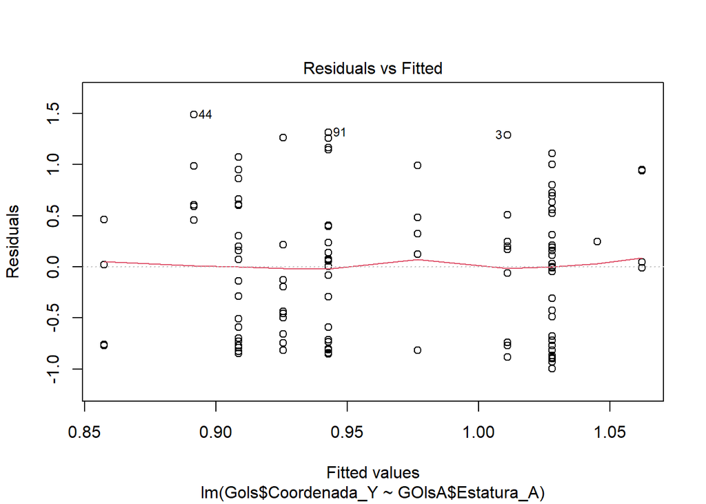

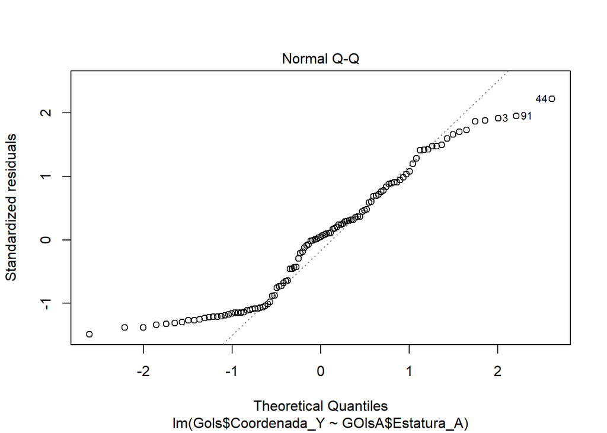

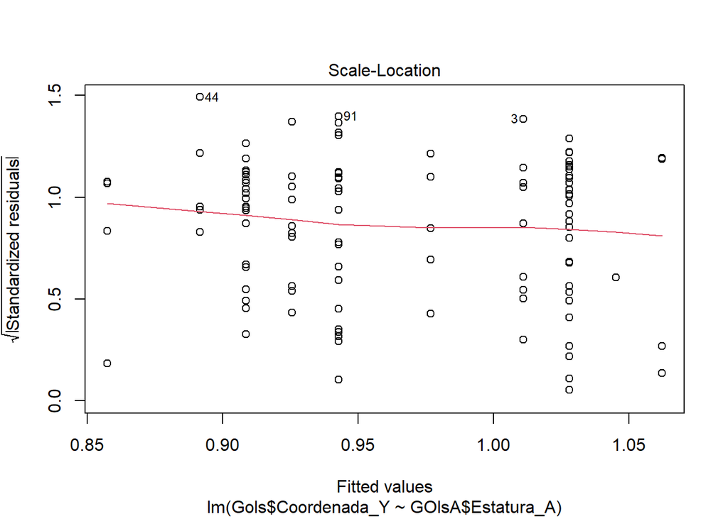

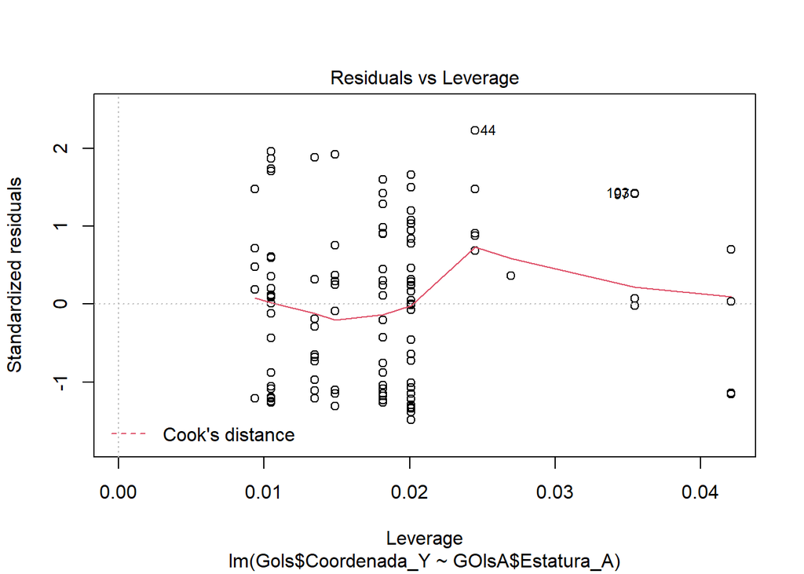

```r
plot(modelo3)
```

```r
summary(modelo3)
```

```
##
## Call:
## lm(formula = Gols$Coordenada_Y ~ GOlsA$Estatura_A)
##
## Residuals:
##     Min      1Q  Median      3Q     Max
## -0.9981 -0.7154  0.0319  0.4960  1.4885
##
## Coefficients:
##                  Estimate Std. Error t value Pr(>|t|)
## (Intercept)       4.18704    3.66855   1.141    0.256
## GOlsA$Estatura_A -0.01708    0.01944  -0.878    0.382
##
## Residual standard error: 0.677 on 109 degrees of freedom
## Multiple R-squared:  0.007027,   Adjusted R-squared:  -0.002083
## F-statistic: 0.7714 on 1 and 109 DF,  p-value: 0.3817
```

Observación al modelo:

En este tercer modelo planteamos la relación entre la variable independiente estatura  
del arquero junto a la ordenada, altura del disparo. Para poder predecir la altura de un disparo en relación a la altura del portero.

Ahora realizaremos el análisis de las gráficas diagnóstico. En cuanto a la homocedasticidad podemos observar una nube de datos que de alguna forma tienden al cero como se esperaría de esta gráfica. Además la línea roja se encuentra en la mayor parte del tiempo sobre la recta horizontal del cero, esta es una gráfica prometedora.

Para la gráfica de Distribución de residuos por momentos parece comportarse como una variable aleatoria normal pero no es el escenario ideal.

En la gráfica de la raíz cuadrada del valor absoluto del residuo estandarizado vemos como la  
línea roja no sigue a la recta horizontal en uno, La recta si bien nace del uno continúa bajando y no sube en ningún momento. A su vez los datos no son tan densos como se esperaría.

En la gráfica de apalancamiento no vemos demasiados datos atípicos salvo tres. Par suerte nuestra, ninguno de los datos atípicos es tiene residuo grandes junto a una palanca grande solo una de las dos cualidades.

Con respecto al resumen de regresión empezaremos el análisis por el acápite de los residuos. Encontramos que la media se aproxima bastante a cero, sin embargo la simetría no es tan evidente como se esperaría en los valores absolutos de los cuartiles.

En el acápite del modelo propuesto (Y=4.18704 - 0.01708 X) nos disponemos a analizar las pruebas de hipótesis. Encontramos que en el caso de la intersección necesitaríamos trabajar con una significancia de casi el 26% para rechazar la hipótesis, algo similar ocurre con la pendiente pues para rechazar la hipótesis tendríamos que trabajar con  
una significancia de poco más del 38% lo que no es para nada alentador. Pasamos a revisar los coeficientes de determinación los que nos dicen qué grado de variación de Y podemos explicar con el modelo y la variación de X. En este caso solo podemos explicar el 0.7% del modelo con esta regresión. Lo que nos deja con un claro mensaje: una variable no depende realmente de la otra. Esto sumado a que no pudimos rechazar la prueba de hipótesis “p-value” nos termina dictando que esta regresión no es útil.

## Cuarto Modelo

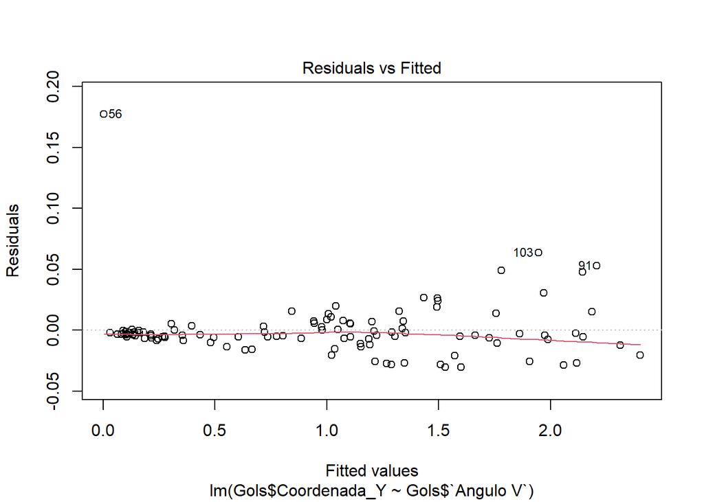

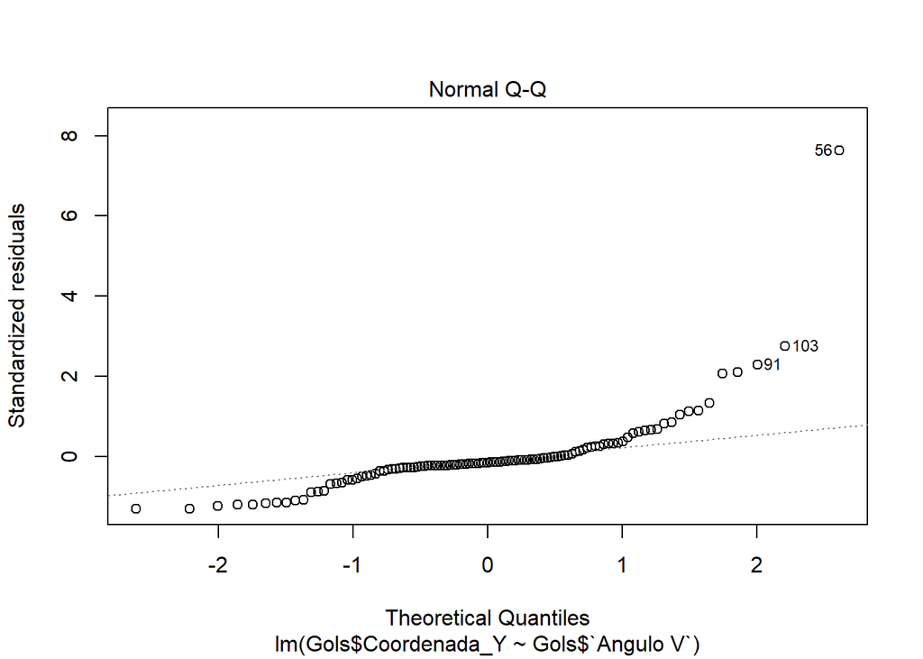

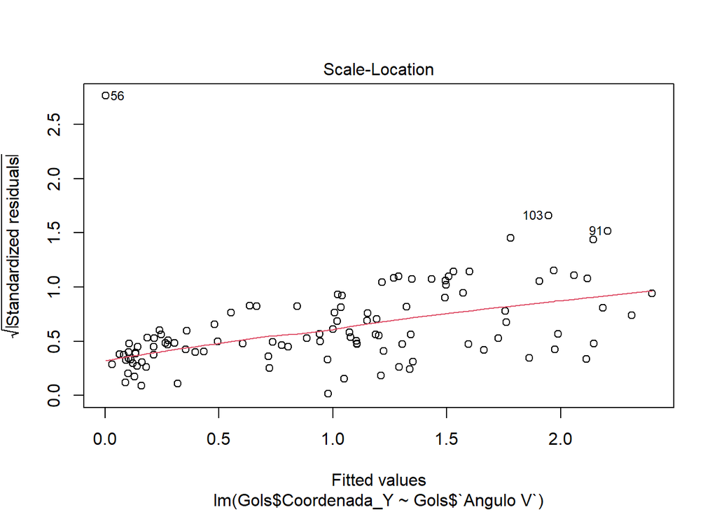

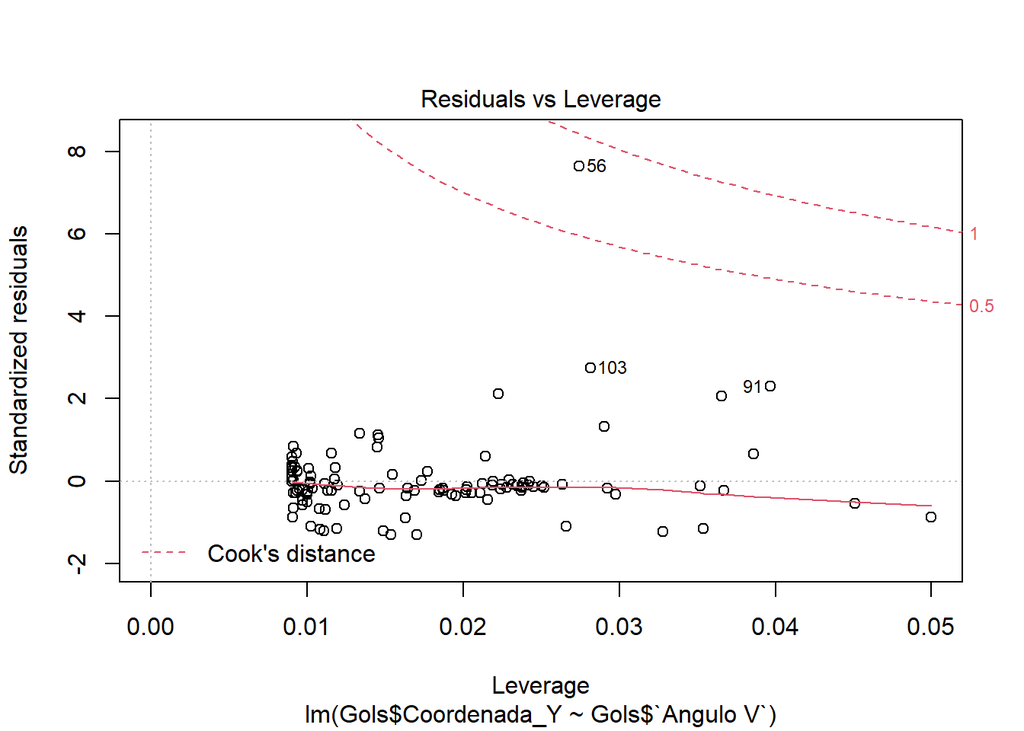

```r
modelo4 <- lm(Gols$Coordenada_Y~ Gols$`Angulo V`)
plot(modelo4)
```

```r
summary(modelo4)
```

```
##
## Call:
## lm(formula = Gols$Coordenada_Y ~ Gols$`Angulo V`)
##
## Residuals:
##       Min        1Q    Median        3Q       Max
## -0.030512 -0.007062 -0.003618  0.002806  0.177214
##
## Coefficients:
##                  Estimate Std. Error t value Pr(>|t|)
## (Intercept)     0.0027862  0.0038970   0.715    0.476
## Gols$`Angulo V` 0.1967400  0.0006528 301.396   <2e-16 ***
## ---
## Signif. codes:  0 '***' 0.001 '**' 0.01 '*' 0.05 '.' 0.1 ' ' 1
##
## Residual standard error: 0.02352 on 109 degrees of freedom
## Multiple R-squared:  0.9988, Adjusted R-squared:  0.9988
## F-statistic: 9.084e+04 on 1 and 109 DF,  p-value: < 2.2e-16
```

Observación al modelo:

En la gráfica de la raíz cuadrada del valor absoluto del residuo estandarizado vemos como la  
línea roja, comforme avanza la ordenada, va aproximándose a 1.

En la gráfica de apalancamiento observamos 3 valores atípicos, de los cuales 56 es el más distante y, por ende, con mayor tendencia de cambiar la recta.

Con respecto al resumen de regresión empezaremos el análisis por el acápite de los residuos. Encontramos que la media se aproxima bastante a cero por el lado negativo (ya que exiten jugadores que patearon afuera del área del arco), sin embargo la simetría no es tan evidente como se esperaría en los valores absolutos de los cuartiles.

# Tendencias y Predicciones

## Primer modelo

Podemos concluir que no es relevante para el entrenador la edad del jugador a la hora de decidir los minutos que jugará en el campo. Esto abre la opción a que el rendimiento físico de estos jugadores no está ligado a su edad en este tipo de competiciones.

## Segundo modelo

Podemos desmentir que, a la hora de patear un penal, los jugadores jóvenes tienden a apresurarse a tirarlo.

## Tercer modelo

Existe una creencia de que a los arqueros altos se les debe patear abajo. Con este modelo, lejos de comprobar si esto es verdadero o falso, hemos notado que, los jugadores en este tipo de competiciones, no le dan una real importancia.

## Cuarto modelo

Como se menciona en el enunciado, la altura de la pelota siempre estará relacionada con la coordenada vertical con la que se pateó el penal. El modelo planteado afirma esta sentencia satisfactoriamente.

# Variables Dependientes

Presentamos las variables dependientes analizadas en la parte de regresión.

En las siguientes gráficas observaremos en la esquina inferior izquierda la correlación de las variables, y en la esquina superior derecha, la regresión ya mostrada en su apartado.

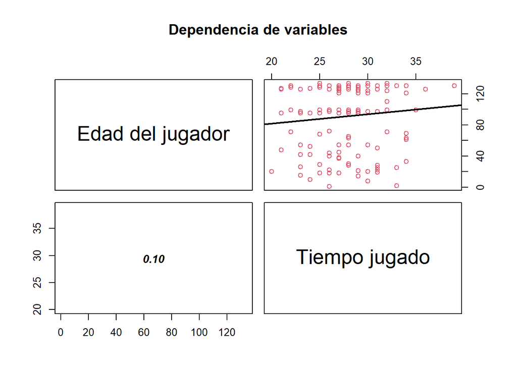

```r
pairs(~DF_J$Tiempo_J + DF_J$Edad_J, col=2, labels=c("Edad del jugador", "Tiempo jugado"), main="Dependencia de variables", lower.panel = panel.cor, upper.panel = reg)
```

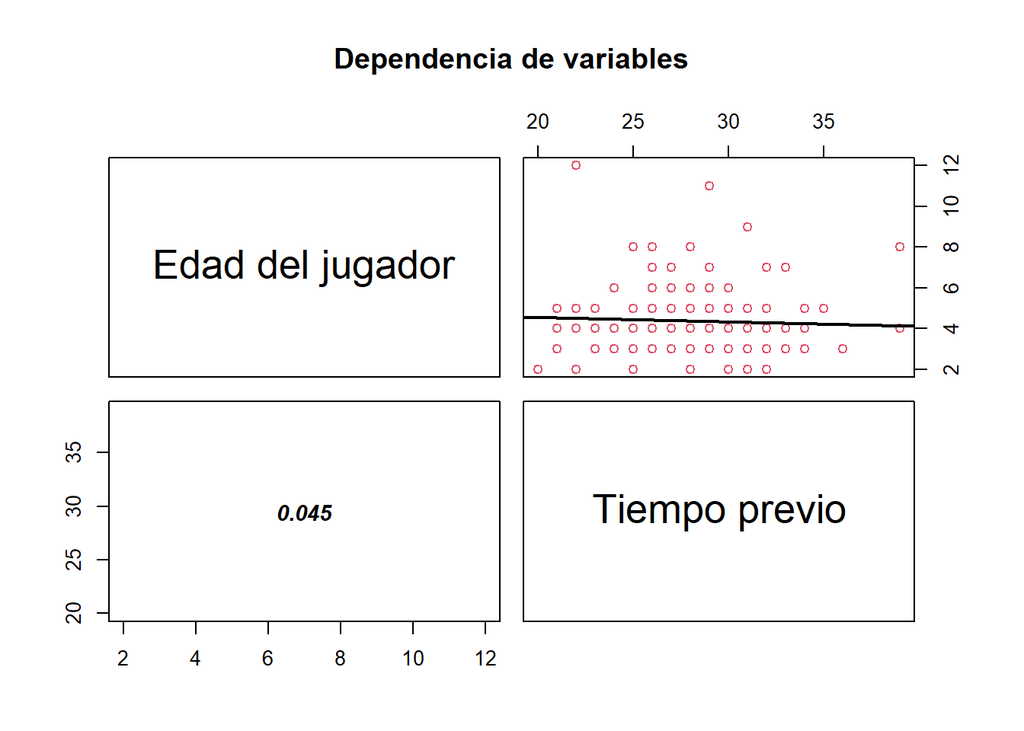

```r
pairs(~DF_J$Tiempo_Prev + DF_J$Edad_J, col=2, labels=c("Edad del jugador", "Tiempo previo"), main="Dependencia de variables", lower.panel = panel.cor, upper.panel = reg)
```

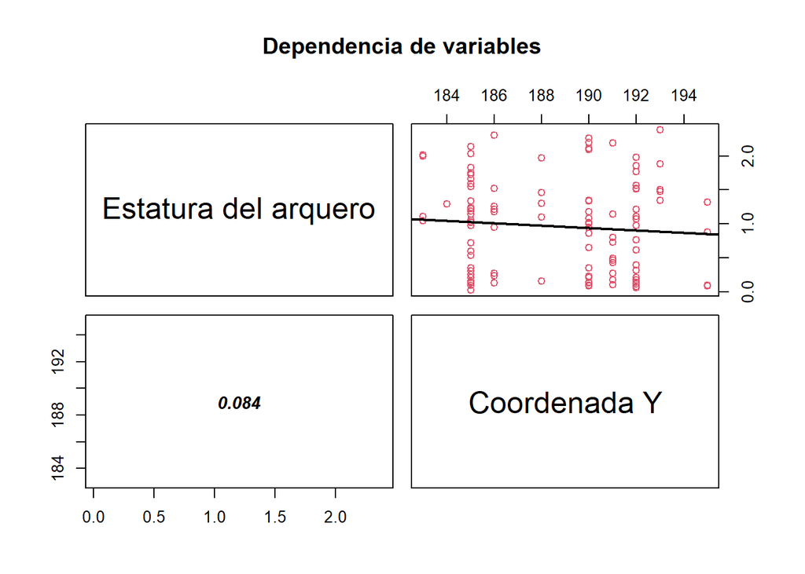

```r
pairs(~ Gols$Coordenada_Y +GOlsA$Estatura_A,col=2,labels=c("Estatura del arquero", "Coordenada Y"),main="Dependencia de variables",lower.panel = panel.cor, upper.panel = reg )
```

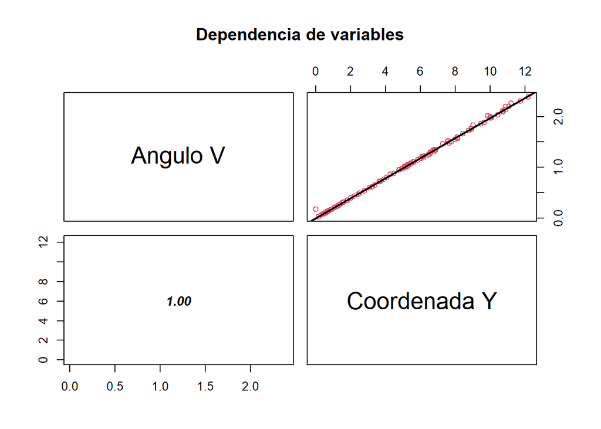

```r
pairs(~ Gols$Coordenada_Y +Gols$`Angulo V`,col=2,labels=c("Angulo V", "Coordenada Y"),main="Dependencia de variables",lower.panel = panel.cor, upper.panel = reg )
```

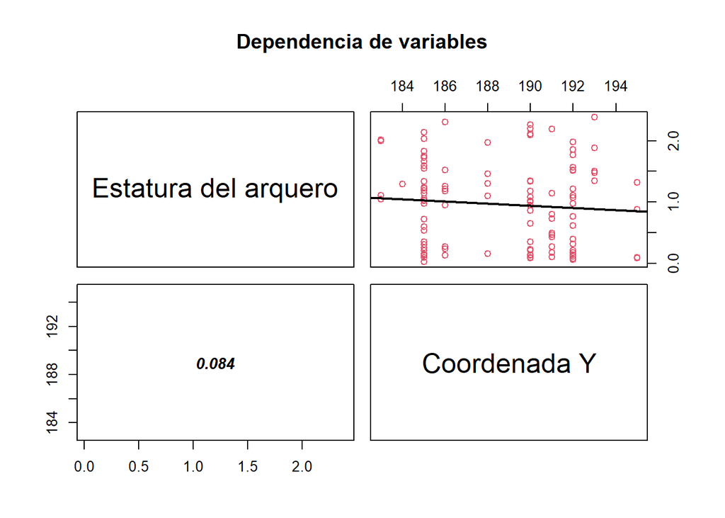

```r
pairs(~ Gols$Coordenada_Y +GOlsA$Estatura_A,col=2,labels=c("Estatura del arquero", "Coordenada Y"),main="Dependencia de variables",lower.panel = panel.cor, upper.panel = reg )
```

A continuación, planteamos las ecuaciones lineales con respecto a los datos obtenidos y que se relacionan con la gráfica de correlación de las variables. Recodemos que se señaló su significancia en la parte de regresión.

```r
f1<-lm( Gols$Tiempo_Prev ~ Gols$Edad_J )
f1
```

```
##
## Call:
## lm(formula = Gols$Tiempo_Prev ~ Gols$Edad_J)
##
## Coefficients:
## (Intercept)  Gols$Edad_J
##      5.3935      -0.0328
```

```r
f2<-lm(Gols$Tiempo_J ~ Gols$Edad_J)
f2
```

```
##
## Call:
## lm(formula = Gols$Tiempo_J ~ Gols$Edad_J)
##
## Coefficients:
## (Intercept)  Gols$Edad_J
##     63.3708       0.9799
```

```r
f3<-lm(Gols$Coordenada_Y~ Gols$`Angulo V`)
f3
```

```
##
## Call:
## lm(formula = Gols$Coordenada_Y ~ Gols$`Angulo V`)
##
## Coefficients:
##     (Intercept)  Gols$`Angulo V`
##        0.002786         0.196740
```

# Conclusiones

Si bien en las gráficas obtuvimos patrones y se pudo observar estadísticas de nuestra muestra, salvo el cuarto modelo, cuyo origen viene netamente de la matemática, no se pudo obtener un modelo de regresión lineal en el cual se evidencie una tendencia de alguna de las variables en relación a otra.

Esta ausencia de relación lineal se debe a que el penal es un evento en el que hay muchos factores que son partícipes en el resultado del mismo. Es por esto que un modelo tan simple como el lineal, en el que solo se involucran dos variables, no puede pretender predecir la naturaleza del evento.

Pese a esta realidad, obtuvimos ciertos datos relevantes a mencionar:

Los jugadores tienden a patear más para el lado izquierdo del arco. (Hipótesis 4)

Los delanteros no tienen el mayor porcentaje de tiro en el primer penal. (Variable Aleatoria)

La estatura del arquero no sesga el tiro de un jugador ni hacia arriba ni abajo. (Regresión)

# Bibliografía

| **Tema** | **Link** |
| --- | --- |
| Base de datos de jugadores | [Perfiles de jugadores profesionales](https://www.transfermarkt.es/) |
| Base de datos del partido | [Resultados de los partidos en los Mundiales](https://www.losmundialesdefutbol.com/) |
| Marco Teórico | [García Martí, C. (2016). “El paso de la defensa individual a la defensa de zona”. Universidad Politécnica de Madrid.](https://oa.upm.es/44626/1/CARLOS_GARCIA_MARTI.pdf) |
| Goles de La Copa América 2019 | [Diario El Comercio (2019). “Copa América 2019: todos los goles anotados en el torneo al detalle, según Mister Chip”](https://elcomercio.pe/deporte-total/copa-america-2019-goles-anotados-torneo-detall… |